# Stat 208 Final Exam

Jordan Berninger

5/29/2020

## Question 1

1. This model includes a location parameter, so we know that $\frac{1}{n}\sum_{i=1}^n(Y_i-\hat{Y_i}) = 0$. Estimated residuals are defined as $\hat{\epsilon_i} = Y_i - \hat{Y_i}$.

Accordingly, $\frac{1}{n}\sum_{i=1}^n(Y_i-\hat{Y_i}) = \frac{1}{n}\sum_{i=1}^n(\hat{\epsilon_i}) = 0$.

Therefore, $\sum_{i=1}^n(\hat{\epsilon_i}) = 0$.

2. We have two cases to solve here, when $n$ is even and when $n$ is odd. We first consider the case where $T$ is even. Note that we can factor the sum into pairs $\sum_{i=1}^ny_i = (y_1 + y_n) + (y_{2}+y_{n-1})$. Accordingly, if we show that each pair sums to zero, then the whole series sums to zero. We now consider our first pair, $\phi^{-1}(1-1/2)/n + \phi^{-1}(n-1/2)/n$.

The bottom plot has green lines at $(i-1/2)/n$, for $i \in 1,\dots,n$. The difference between the top and bottom plot is the location transformation, each green line is shifted by $-1/2n = -1/12$.

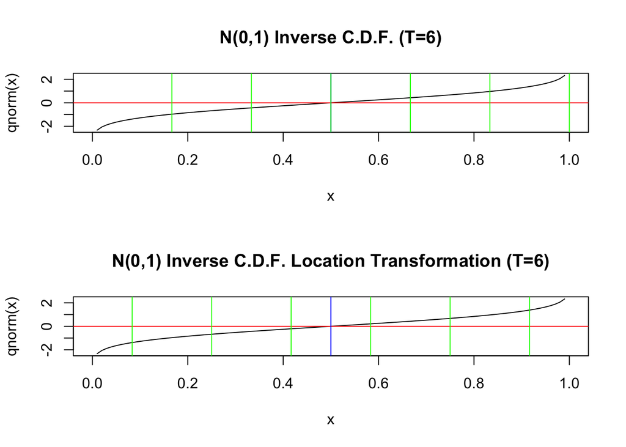

```r
n=6
j=c(1:n)
par(mfrow=c(2,1))
x=seq(from=0,to=1,0.01)
plot(x,qnorm(x),type="l",main="N(0,1) Inverse C.D.F. (T=6)")
abline(h=0,col="red")
abline(v=0.5,col="blue")
for(i in 1:n){
  abline(v=j[i]/n,col="green")
}
plot(x,qnorm(x),type="l",main="N(0,1) Inverse C.D.F. Location Transformation (T=6)")
abline(h=0,col="red")
abline(v=0.5,col="blue")
for(i in 1:n){
  abline(v=(j[i]-0.5)/n,col="green")
}
```

This transformation makes each pair of our sum $(y_1 + y_n) + (y_{2}+y_{n-1})$ symmetric around the origin. Considering the symmetry of $\phi^{-1}$, this means that $\phi^{-1}(1-1/2)/n + \phi^{-1}(n-1/2)/n$. By the same logic, each pair in the sum evaluates to zero.

Now we want to consider the case where $n$ is odd. This summation can be factored as, $\sum_{i=1}^ny_i = (y_1 + y_n) + (y_2 + y_{n_1}) + \dots + y_{(n+1)/2}$. By the same logic as above, each pair in sums to zero. Since $n$ is odd, clearly, the $\frac{n+1}{2}$ element cannot find a match in this ordering. We note that $\phi^{-1}((n+1)/2-1/2)/n)=\phi^{-1}(1/2)=0$, and therefore the entire series sums to zero when $n$ is odd.

3. First we note the the trigonometric identity: $cos(2 \pi t/T) = \frac{1}{2sin(2\pi/T)}(sin(2\pi(t+1)/T) - sin(2\pi(t-1)/T))$

$$\begin{aligned}
\sum_{t=1}^{T}cos(2\pi t/T) &= \frac{1}{2sin(2\pi/T)}\Big(sin(2\pi(n+1)/T)) - \\
& sin(2\pi n/T) - sin(2\pi/T) - sin(2\pi(1-1)/T)\Big) \\
\end{aligned}$$